# Mapping Raster and Vector Data, Part 1

Introduction to Rasters

Author

Brittany Barker

Published

June 17, 2025

## **Load packages**

```r
library(here) # Easier relative paths
library(dplyr) # Data wrangling
library(lubridate) # Working with dates
library(ggplot2) # Plotting model outputs
library(ggthemes) # ggthemes_data function
library(patchwork) # Combine plots
library(viridis) # Color palettes for ggplot2
library(knitr) # Including graphics
library(sf) # Working with spatial features
library(terra) # Working with rasters
library(tidyterra) # Tidyverse function for SpatRaster objects
#library(USAboundaries) # USA boundary features
# issues w/ installing "USAboundaries" so run this code
#devtools::install_github("ropensci/USAboundaries")
```

## **Overview**

Combine the [`terra`](https://rspatial.org/pkg/index.html), [`sf`](https://r-spatial.github.io/sf/), and [`ggplot2`](https://ggplot2.tidyverse.org/) packages to work with geospatial data and create beautiful maps.

### **Learning objectives**

- Plot and analyze spatial data to address a research question
- Apply different mapping functions in `terra`, `sf`, and `ggplot2`
- Describe the difference between vector and raster features
- Describe the influence of a coordinate reference system (CRS) on mapping
- Adjust `ggplot2` settings to customize maps

## **Mapping predicted vs. observed dates of lilac phenophases**

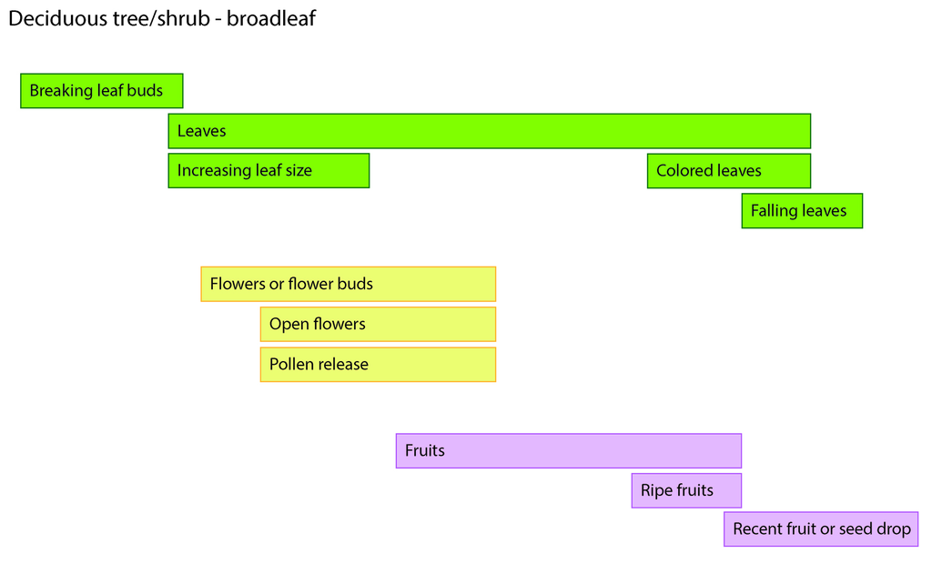

In the following exercises, we will visualize spatial concordance between model-predicted and observed dates of lilac leaf out, which is a phenophase of lilac in which new leaves appear. A **phenophase** is an observable stage of an animal’s or plant’s life cycle that can be defined by a start and end point. All data were derived from the [USA National Phenology Network](https://www.usanpn.org/usa-national-phenology-network), an organization that hosts phenology models and maintains a database of volunteer-contributed observations of phenology for ecologically and economically important species of plants and insects in the USA.

## **Exercise 1: Mapping predicted lilac leaf out**

We import raster data for model predictions of lilac leaf out for 2018 using the `rast()` function in `terra`.

```r
lilacModel_r <- rast(here("data", "lilac_2018_model.tiff"))
```

Check out attributes of the raster, such as it’s class, coordinate reference system (crs), class, extent, and range of values correspond to the day in which lilac leaf out was predicted to occur in `2018`.

```r
class(lilacModel_r)
```

```
[1] "SpatRaster"
attr(,"package")
[1] "terra"
```

```r
lilacModel_r
```

[output not shown]

We’ll go over three approaches for mapping this raster.

#### **(1a) terra: `plot()`**

The raster can be visualized using the [`plot()` function in `terra`](https://rspatial.github.io/terra/reference/plot.html). This function can produce some decent looking maps, but not as nice as `ggplot2` maps (in my opinion). Try it out below.

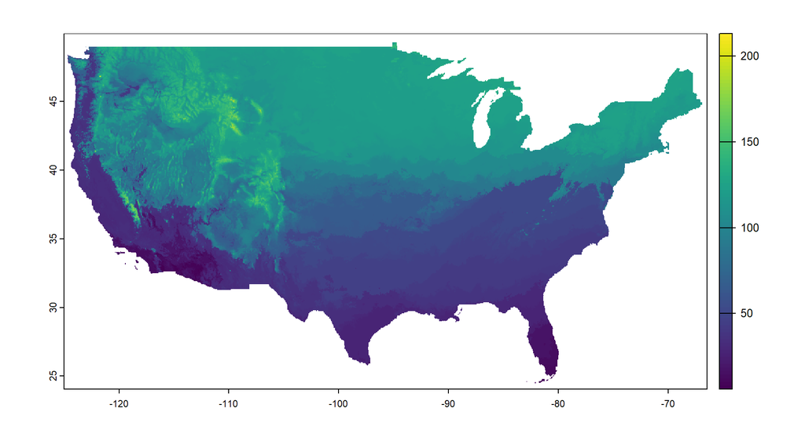

The color palette can changed using the `col` option. The default is `rev(grDevices::terrain.colors(50))`. Can you find a palette that you like better? (e.g., check out other palettes in `viridis` by typing `viridis::`).

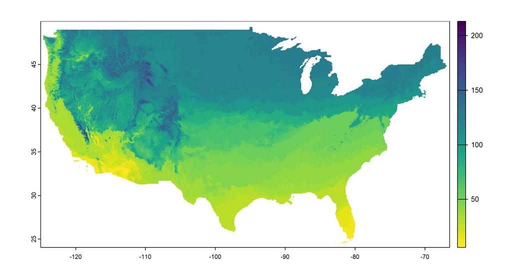

Raster data can be depicted in bins by specifying “interval” for the `type` option. The number of intervals is defined with the `breaks` option. Apply different numbers of breaks to see how it affects your map.

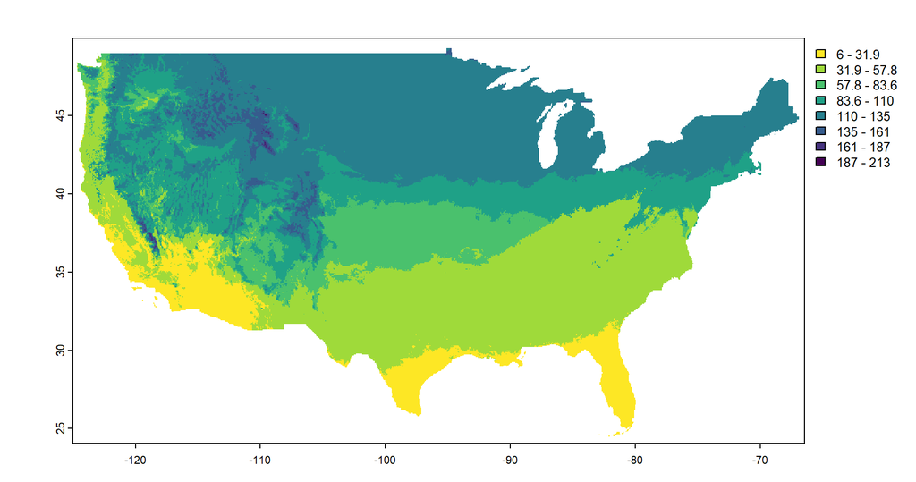

You can also classify the bins yourself using the `classify()` function. Try changing the `classes` object in the code below to see how it impacts the map.

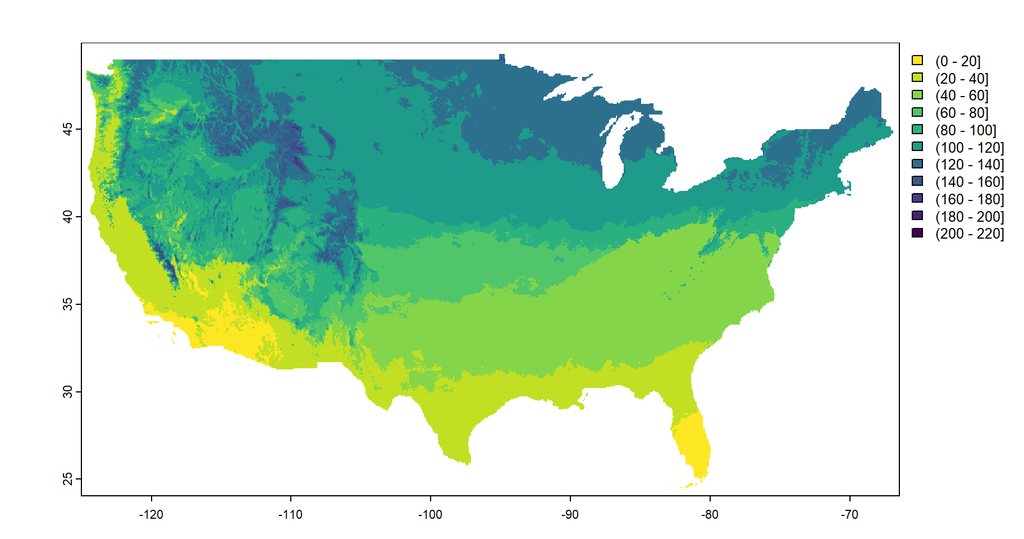

**Question 1.** How does predicted lilac leaf out vary across the contiguous U.S. (CONUS)? Any ideas what may explain these patterns?

Answer: Leaf out occurs earlier in southern latitudes because warmer temperatures there drive faster development.

The `plot()` function has several other options for customizing maps. Below, I added a title, put axis labels on 3 sides.

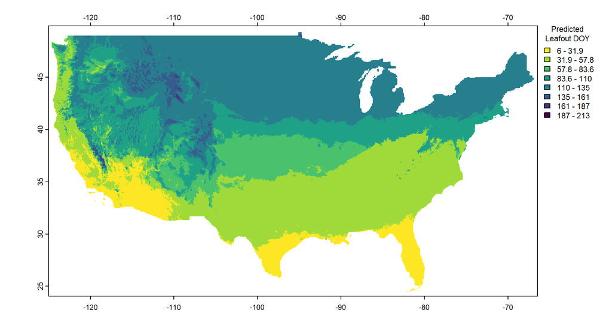

#### **(1b) Plotting rasters in ggplot2**

Most people are more familiar with tidyverse packages and functions than those in `terra` or its predecessor `raster`. Thus, mapping rasters with `ggplot2` is often preferred over `plot()`. We’ll cover two `ggplot2` functions: (1) `geom_raster()`, which requires data to be in data frame format, and (2) `geom_spatraster()`, which can work directly with `SpatRaster` objects. The latter function is part of the relatively new [`tidyterra` package](https://dieghernan.github.io/tidyterra/). For both examples, days of the year will be binned into months to facilitate comparisons with observed lilac leaf out dates (Exercise 2, below). This task requires defining a factor variable, as described below.

#### **ggplot2: `geom_raster()`**

First, convert the raster into a data frame using `as.data.frame()` in `terra.` Set the `xy` option to `TRUE` to retain coordinate information (`x` and `y` columns), and rename the data column from `layer` to `leaf_doy.`

```r
# Convert raster data to a data frame
lilacModel_df <- lilacModel_r %>%
  as.data.frame(xy = TRUE) %>%
  rename("leaf_doy" = layer)
head(lilacModel_df)
```

```
              x        y leaf_doy
71692 -95.15470 49.35805      121
71693 -95.13223 49.35805      121
71694 -95.10977 49.35805      121
71695 -95.08731 49.35805      121
71696 -95.06484 49.35805      125
71697 -95.04238 49.35805      125
```

Next, we create a data frame that specifies the month for each day of year, which will be used for defining factor levels and for plotting in `ggplot2`.

```r
# Data frame needed to create pretty plots
factors_df <- data.frame(
  # Day and month of year
  leaf_doy= 1:365,
  leaf_month = cut_interval(1:365, 12)) %>%
  # Bin dates by month and re-format labels to remove brackets, parentheses, etc.
  mutate(leaf_month = format(as.Date(
    leaf_doy, origin = "2018-01-01"), "%b"),
    leaf_month = gsub("\\(|\\]|\\[", "", leaf_month)) %>%
  mutate(leaf_month = gsub(",", "-", leaf_month))

# Convert month to a factor so they're in the right order on plots
# Factor levels are ordered by day of the year
factors_df$leaf_month <- factor(
  factors_df$leaf_month,
  levels = unique(factors_df$leaf_month[order(factors_df$leaf_doy)]))
```

Join the data frame with factor levels to `lilacModel_df` and examine its structure. To do this, use `left_join()` from the `dplyr` package.

```r
# Join month labels to lilac predictions
lilacModel_df <- left_join(lilacModel_df, factors_df, by = "leaf_doy")
head(lilacModel_df)
```

```
          x        y leaf_doy leaf_month
1 -95.15470 49.35805      121        May
2 -95.13223 49.35805      121        May
3 -95.10977 49.35805      121        May
4 -95.08731 49.35805      121        May
5 -95.06484 49.35805      125        May
6 -95.04238 49.35805      125        May
```

Next, we create some custom labels for the plots, and define a pretty color palette.

```r
# Create a vector of labels to show in plot legend
labs <- unique(factors_df$leaf_month)

# Create a color palette (vector) for the plot
pal <- c("#1f83b4", "#12a2a8", "#2ca030", "#78a641", "#bcbd22", "#ffbf50",
         "#ffaa0e", "#ff7f0e","#d63a3a", "#c7519c", "#ba43b4", "#8a60b0")
names(pal) <- unique(factors_df$leaf_month) # Name colors by month
```

Finally, the `lilacModel_df` data frame can be plotted using `geom_raster()`.

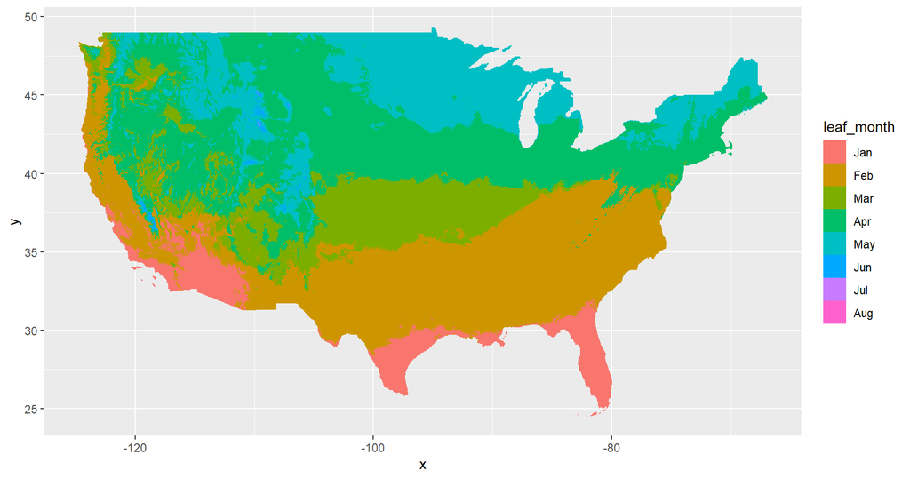

This map looks okay but can definitely be improved. For example, we could add a plot title, custom legend title, and maybe get rid of the default gray background, grid lines, and axes labels. First add the titles.

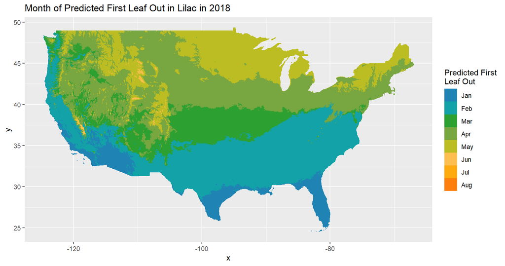

Now customize the map theme. If you’re producing multiple plots, it’s more concise to define your custom theme a single time (DRY principle = Don’t Repeat Yourself).

```r
# Custom theme
my_theme <- theme(#panel.grid= element_blank(),
                 panel.background = element_blank(),
                 panel.border = element_rect(fill = NA),
                 axis.title = element_blank(),
                 #axis.text = element_blank(),
                 #axis.ticks = element_blank(),
                 plot.title = element_text(face = "bold", size = 16),
                 legend.key = element_rect(fill = "white"),
                 legend.title = element_text(face="bold", size = 12),
                 legend.text = element_text(size = 11),
                 legend.key.height = unit(0.0025, "cm"),
                 legend.key.width = unit(1, "cm"))
```

Apply the custom theme to the plot.

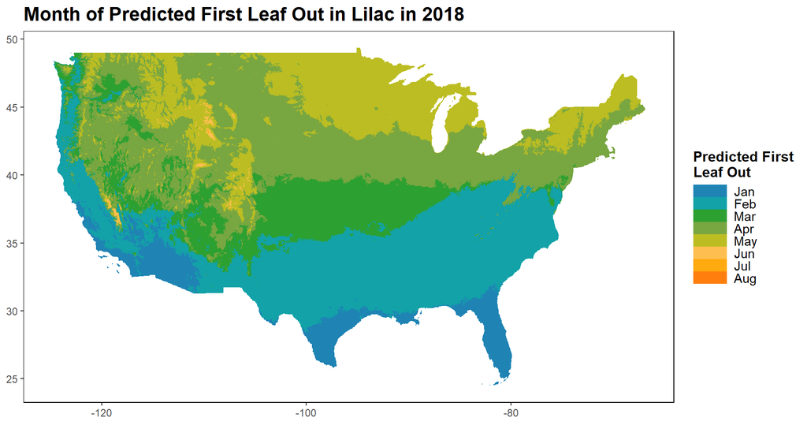

**Challenge 1.** Change at least two plot features to align with your preferences. For example, you could remove the plot axes (lat and long), change the legend attributes, font types and sizes, etc. (`my_theme`), or change the color palette (`pal`).

FYI: The [`ggsn`](https://oswaldosantos.github.io/ggsn/) package has functions to add a scale bar and north arrow. Check it out sometime!

#### **Adding boundary data to maps**

The map is more informative if we add state boundaries. Some R packages provide these data, including [`rnaturalearth`](https://github.com/ropensci/rnaturalearth) and [`USAboundaries`](https://docs.ropensci.org/USAboundaries/); however, installing them can sometimes be problematic. To avoid troubleshooting, I saved USA boundary data as shapefiles. First, we need to use `st_use_s2(FALSE)` because `sf` assumes the world is round, and uses great circles for straight lines. This will cause issues for cropping boundaries to the same extent as our raster data. See [here](https://r.geocompx.org/reproj-geo-data) for more information about the S2 spherical geometry engine.

```r
sf_use_s2(FALSE)
```

```
Spherical geometry (s2) switched off
```

Now import the shapefile using the `st_read()` function and plot the first column.

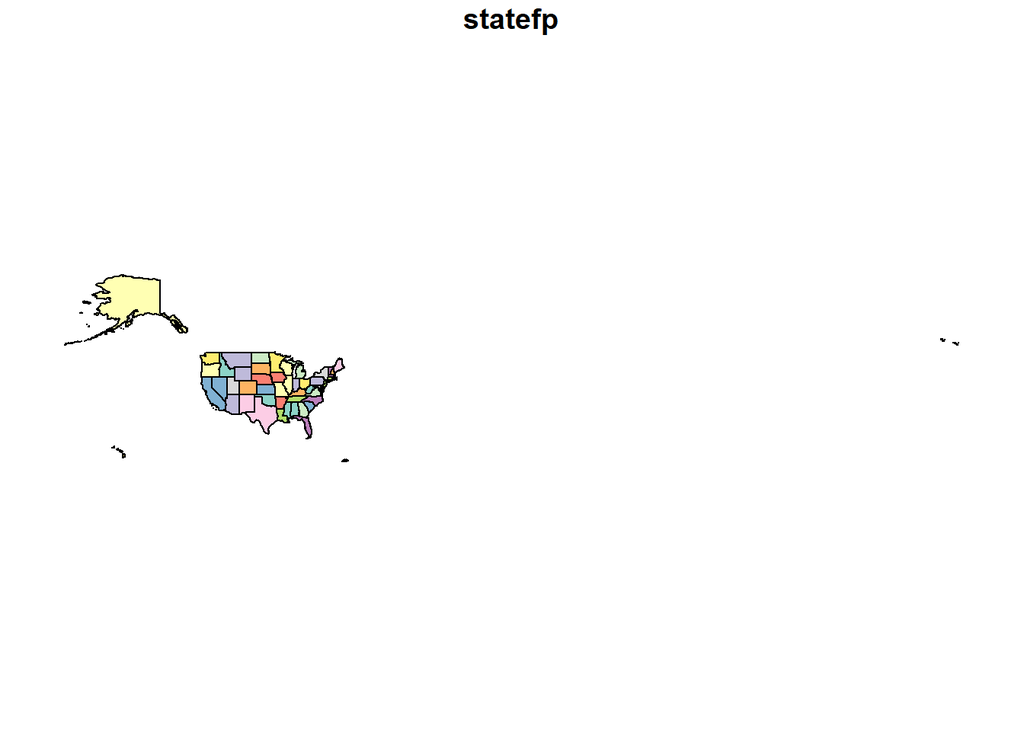

```r
# US states feature
states <- st_read(here("data", "states.shp"))
# Plot the first data column
plot(states[1])
```

**Question 2.** What is the class and geometry type of `states`? Describe two other differences between `states` and `lilacModel_r`.

Answer: the class is both `sf` and `data.frame`. The `sf` portion contains geographic information such as geometry, extent, and CRS, whereas the data frame has associated data, such as state names and abbreviations. In contrast, `lilcModel_r` is raster data contained in a `SpatRaster` object. The raster data are gridded and cover the entire CONUS, whereas the sf data are a vector of state boundaries. The two datasets are similar in that they have a CRS, a geographic extent, and spatial information.

We’re going to run into issues due to differing coordinate reference systems (CRS) of `states` and `lilacModel_r`. You can see these differences by using the `crs()` function on both objects.

CRS of `states`.

```r
# CRS of states
crs(states)
```

```
[1] "GEOGCRS[\"WGS 84\",\n    DATUM[\"World Geodetic System 1984\",\n        ELLIPSOID[\"WGS 84\",6378137,298.257223563,\n            LENGTHUNIT[\"metre\",1]]],\n    PRIMEM[\"Greenwich\",0,\n        ANGLEUNIT[\"degree\",0.0174532925199433]],\n    CS[ellipsoidal,2],\n        AXIS[\"geodetic latitude …
```

CRS of `lilacModel_r`.

```r
# CRS of lilacModel_r
crs(lilacModel_r)
```

```
[1] "GEOGCRS[\"NAD83\",\n    DATUM[\"North American Datum 1983\",\n        ELLIPSOID[\"GRS 1980\",6378137,298.257222101004,\n            LENGTHUNIT[\"metre\",1]]],\n    PRIMEM[\"Greenwich\",0,\n        ANGLEUNIT[\"degree\",0.0174532925199433]],\n    CS[ellipsoidal,2],\n        AXIS[\"geodetic latitu…
```

Change the CRS of states to match the raster data using `st_transform`. Check out the results.

```r
# Transform coordinates of states
states <- st_transform(states, crs(lilacModel_r))
crs(states)
```

```
[1] "GEOGCRS[\"NAD83\",\n    DATUM[\"North American Datum 1983\",\n        ELLIPSOID[\"GRS 1980\",6378137,298.257222101004,\n            LENGTHUNIT[\"metre\",1]]],\n    PRIMEM[\"Greenwich\",0,\n        ANGLEUNIT[\"degree\",0.0174532925199433]],\n    CS[ellipsoidal,2],\n        AXIS[\"geodetic latitu…
```

Next, use `st_crop()` to crop your states feature to the same extent as your raster, which is CONUS. Check out the results. What happens if you skip the `st_transform()` step and run this code?

```r
# Crop to CONUS
states_c <- st_crop(states, lilacModel_r)
```

```
although coordinates are longitude/latitude, st_intersection assumes that they
are planar
```

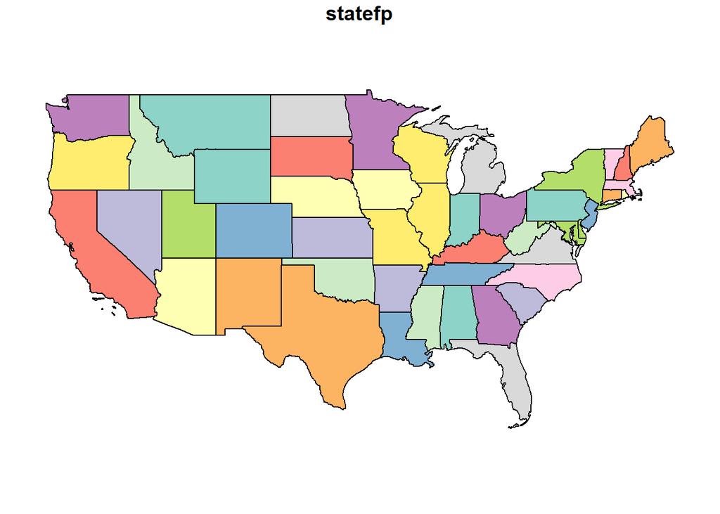

```r
# Plot the result
plot(states_c[1])
```

**Challenge 2.** Can you think of a `dplyr` approach to obtaining data only for CONUS? Hint: remove rows with undesired states (note that Puerto Rico [PR] is in the data).

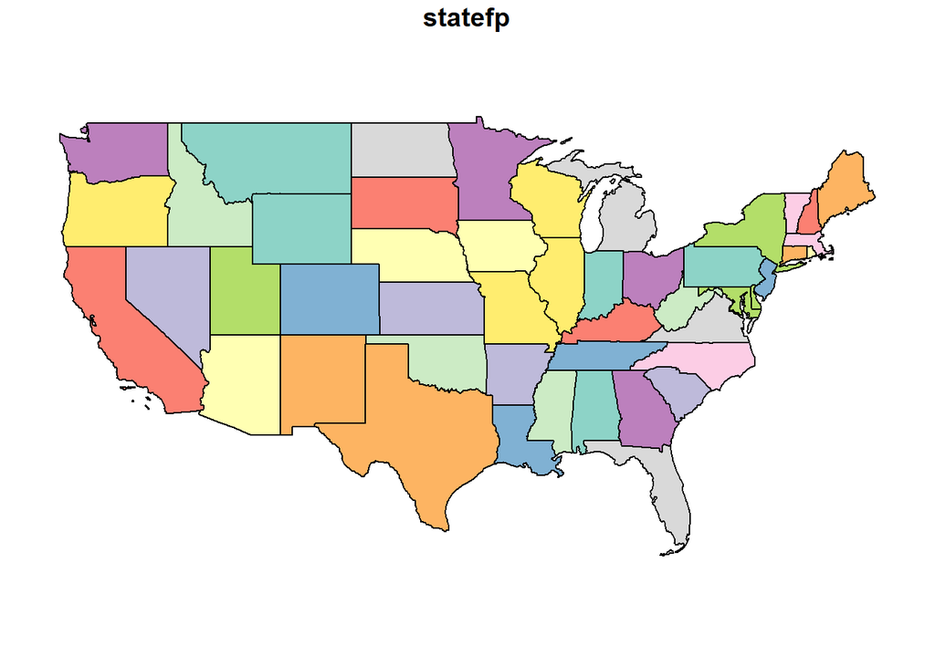

```r
states_c2 <- filter(states, !stusps %in% c("AK", "HI", "PR"))
plot(states_c2[1])
```

Finally, use `geom_sf()` to add an `sf` object to a plot - i.e., the states feature.

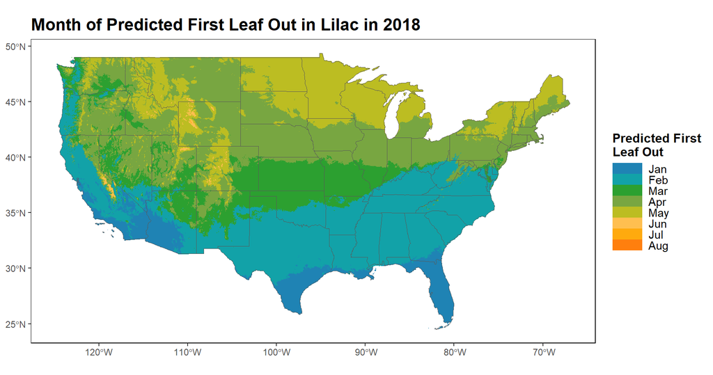

**Question 3.** What happens when you don’t enter `NA` for the fill option for the `states_c` feature? Why?

Answer: the states features covers up the raster data because it’s multi-polygon data. The default fill color is gray.

You could just continue to use fill = `NA`, or convert the geometry of `states_c` to `MULTILINESTRING` using the `st_cast()` function.

```r
# Convert geometry from polygon to multilinestring
states_c %>%
  st_cast("MULTILINESTRING")
```

```
Simple feature collection with 49 features and 12 fields
Geometry type: MULTILINESTRING
Dimension:     XY
Bounding box:  xmin: -124.7258 ymin: 24.49813 xmax: -66.9499 ymax: 49.38436
Geodetic CRS:  NAD83
First 10 features:
   statefp  statens     affgeod geoid stusps       name lsad        aland
1       06 01779778 0400000US06    06     CA California   00 403671196038
2       55 01779806 0400000US55    55     WI  Wisconsin   00 140292246684
3       16 01779783 0400000US16    16     ID      Idaho   00 214049923496
4       27 00662849 0400000US27    27     MN  Minnesota   00 206232157570
5       19 01779785 0400000US19    19     IA       Iowa   00 144659688848
6       29 01779791 0400000US29    29     MO   Missouri   00 178052563675
7       24 01714934 0400000US24    24     MD   Maryland   00  25151895765
8       41 01155107 0400000US41    41     OR     Oregon   00 248628426864
9       26 01779789 0400000US26    26     MI   Michigan   00 146614604273
10      30 00767982 0400000US30    30     MT    Montana   00 376973673895
         awater    stat_nm stt_bbr jrsdct_                       geometry
1   20294133830 California      CA   state MULTILINESTRING ((-118.4848...
2   29343721650  Wisconsin      WI   state MULTILINESTRING ((-86.83575...
3    2391577745      Idaho      ID   state MULTILINESTRING ((-117.2151...
4   18949864226  Minnesota      MN   state MULTILINESTRING ((-96.93096...
5    1085996889       Iowa      IA   state MULTILINESTRING ((-96.57794...
6    2487215790   Missouri      MO   state MULTILINESTRING ((-95.53318...
7    6979171386   Maryland      MD   state MULTILINESTRING ((-76.00734...
8    6170953359     Oregon      OR   state MULTILINESTRING ((-124.4809...
9  103872203398   Michigan      MI   state MULTILINESTRING ((-84.51789...
10   3866689601    Montana      MT   state MULTILINESTRING ((-115.501 ...
```

You can add labels to your map using the `geom_sf_text()` or `geom_sf_label()` functions. State abbreviations can be shown by selecting “stusps” as the `label` in the `aes()` function.

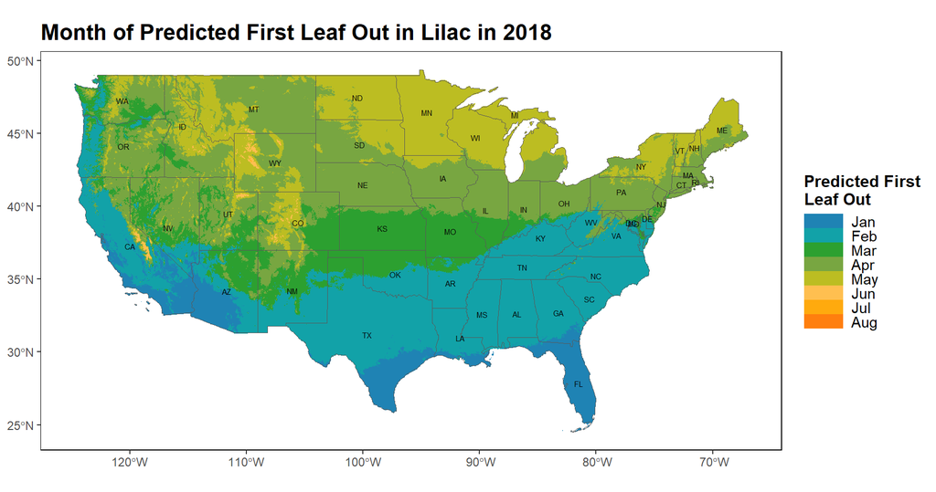

An identical map can be produced using the `geom_spatraster()` function in `tidyterra`, which works directly with `SpatRaster` objects. First, create a copy of your raster and convert the data into categorical (factor) format for plotting. The `factors_df` data frame is used to define factor levels.

```r
# Define factor levels of the raster using the "factors_df" data frame
lilacModel_r2 <- lilacModel_r
levels(lilacModel_r2) <- factors_df
```

Look at both rasters and notice the data formats.

```r
# Original raster (numeric data - days of the year)
lilacModel_r
```

[output not shown]

```r
# New raster (categorical data - months of the year)
lilacModel_r2
```

```
class       : SpatRaster
dimensions  : 1228, 2606, 1  (nrow, ncol, nlyr)
resolution  : 0.02246419, 0.02107085  (x, y)
extent      : -125.0208, -66.47917, 24.0625, 49.9375  (xmin, xmax, ymin, ymax)
coord. ref. : lon/lat NAD83 (EPSG:4269)
source      : lilac_2018_model.tiff
categories  : leaf_month
name        : leaf_month
min value   :        Jan
max value   :        Aug
```

Create the same map as before but instead use `geom_spatraster()` with your categorical raster instead of `geom_raster()`. Name it `conus_mod`.

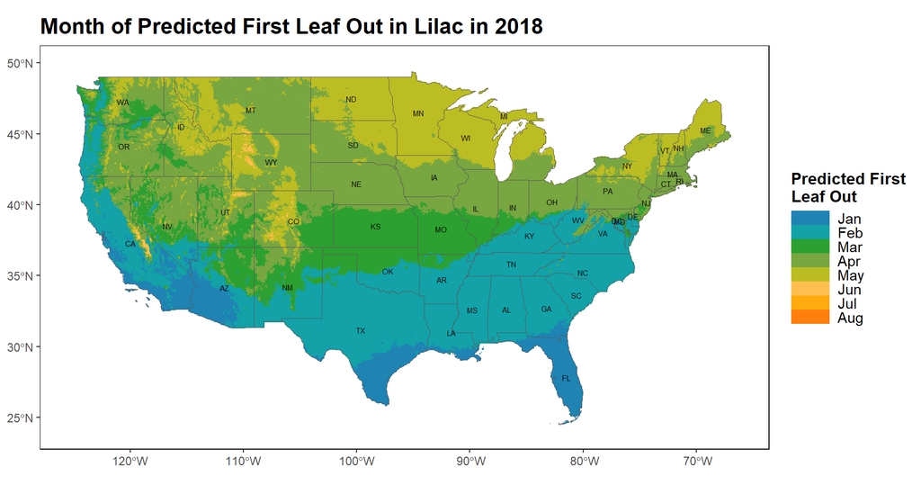

Save your map using `ggsave()` and see how it looks. If you’re not happy with it, adjust the image dimensions of change the plot theme (i.e., `my_theme`).

## **Exercise 2: Adding phenometric data to the map**

We can add more layers to our map to ask certain questions, such as: How do model-predicted dates of lilac leaf out compared with observed dates? Below, we import phenometric data for observed lilac leaf out dates for 2018. These data were collected by volunteers and submitted to the USA National Phenology Network’s database.

```r
# Phenometric data
lilacObs_df <- read.csv(here("data", "lilac_2018_obs.csv"))
```

Take a look at the data dimensions. How many observations are there?

```r
dim(lilacObs_df)
```

```
[1] 182  25
```

There are 77 unique sites in the dataset. The goal is to add the location for each observation to our previous map.

```r
length(unique(lilacObs_df$site_id))
```

```
[1] 77
```

We only need data in three columns in the phenometric data: `longitude`, `latitude`, and `first_yes_doy`. The `first_yes_doy` column specifies the day of year when first lilac leaf out was observed. We’ll subset the columns using `select()` and take a look at the first several rows of data.

```r
lilacObs_df <- lilacObs_df %>%
  filter(state != "ON") %>% # Remove an observation from Canada
  dplyr::select("longitude", "latitude", "first_yes_doy") %>%
  rename("leaf_doy" = "first_yes_doy") %>%
  left_join(factors_df, by = "leaf_doy")
```

Take a look at the first several rows of data.

```r
head(lilacObs_df)
```

```
  longitude latitude leaf_doy leaf_month
1 -87.89300 43.09780      121        May
2 -87.89300 43.09780      121        May
3 -92.75200 36.52450       53        Feb
4 -83.05769 43.72269      118        Apr
5 -76.55337 38.88813       57        Feb
6 -76.55337 38.88813       57        Feb
```

For plotting purposes, we convert the phenometric data to a simple feature (`sf`) object using the [`st_as_sf()`](https://www.rdocumentation.org/packages/sf/versions/1.0-9/topics/st_as_sf) function. You must specify which columns contain the coordinates, and also define the CRS, which should be the same as our other objects.

```r
# Convert data frame to a simple feature
lilacObs_sf <- lilacObs_df %>%
   st_as_sf(coords = c("longitude", "latitude"), crs = crs(states))
```

We’ll save the file for use in the next exercise. The extension `.shp` makes it save as an ESRI Shapefile. Note: GDAL requires that column names are <=10 characters long.

```r
# Shorten names
names(lilacObs_sf) <- c("leaf_doy", "leaf_month", "geometry")
st_write(lilacObs_sf, here("data", "lilac_2018_obs.shp"), append = TRUE)
```

```
Updating layer `lilac_2018_obs' to data source `C:/Users/barkebri/Documents/R/Cascadia_R_Conf/CASCADIA_R_Intro_to_GIS_2025/data/lilac_2018_obs.shp' using driver `ESRI Shapefile'
Updating existing layer lilac_2018_obs
Writing 181 features with 2 fields and geometry type Point.
```

Compare the geometry of `lilacObs_sf` and `states`.

```r
# Lilac observations feature
lilacObs_sf$geometry
```

```
Geometry set for 181 features
Geometry type: POINT
Dimension:     XY
Bounding box:  xmin: -122.7566 ymin: 35.01538 xmax: -70.89148 ymax: 47.95269
Geodetic CRS:  NAD83
First 5 geometries:
```

```
POINT (-87.893 43.0978)
POINT (-87.893 43.0978)
```

```
POINT (-92.752 36.5245)
```

```
POINT (-83.05769 43.72269)
```

```
POINT (-76.55337 38.88813)
```

```r
# States feature
states$geometry
```

```
Geometry set for 52 features
Geometry type: MULTIPOLYGON
Dimension:     XY
Bounding box:  xmin: -179.1743 ymin: 17.91377 xmax: 179.7739 ymax: 71.35256
Geodetic CRS:  NAD83
First 5 geometries:
```

```
MULTIPOLYGON (((-118.594 33.4672, -118.4848 33....
```

```
MULTIPOLYGON (((-86.93428 45.42115, -86.83575 4...
```

```
MULTIPOLYGON (((-117.243 44.39097, -117.2151 44...
```

```
MULTIPOLYGON (((-97.22904 49.00069, -96.93096 4...
```

```
MULTIPOLYGON (((-96.62187 42.77925, -96.57794 4...
```

**Question 4.** How does the geometry of the lilac observations (`lilacObs_sf`) differ from the states feature? Why?

Answer: the lilac observations have a POINT geometry whereas the states data have a MULTIPOLYGON geometry. Observations are from single locations, whereas state boundaries cover many points over the U.S.

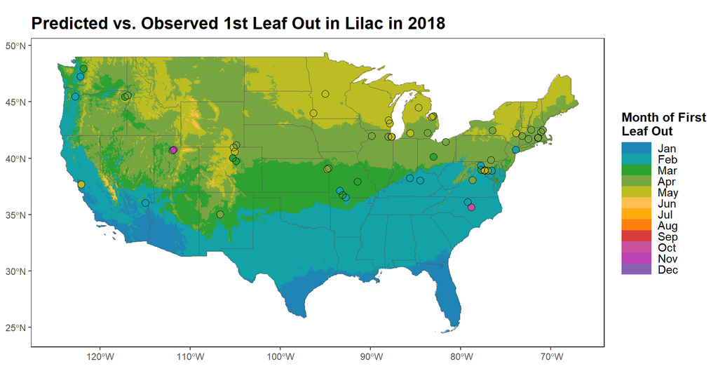

Save your map using `ggsave()` and see how it looks. If you’re not happy with it, adjust the image dimensions or change the plot theme (i.e., `my_theme`).

```r
ggsave(conus_modVobs,
       filename = here("plots", "Lilac_leaf_out_modelVsObs_2018.png"),
       dpi = 300, units = c('in'), width = 10, height = 6)
```

**Question 5.** What does your map tell you about predicted vs. observed first leaf out in lilac? Can you think of a better way to compare the two datasets on a map?

Answer: Our map indicates that predicted dates of lilac leaf out in 2018 did not always correspond to observed dates. In some cases, the model seems to under-predict dates (leaf out too early) whereas in others it over-predicts (leaf out too late). Notice that two sites had dates that were much later than predicted dates. In this case, perhaps the volunteers failed to notice that lilac leaf out had already occurred, although other explanations are possible.

#### **Combining different maps**

Let’s say we’re interested in results for a particular region of CONUS, such as a state. The map can be zoomed with the `coord_sf()` function, in which the x- and y-limits of the region are defined. In the commented `coord_sf()` function below, enter your own limits (xmin, xmax, ymin, ymax), but make sure they’re within the U.S.

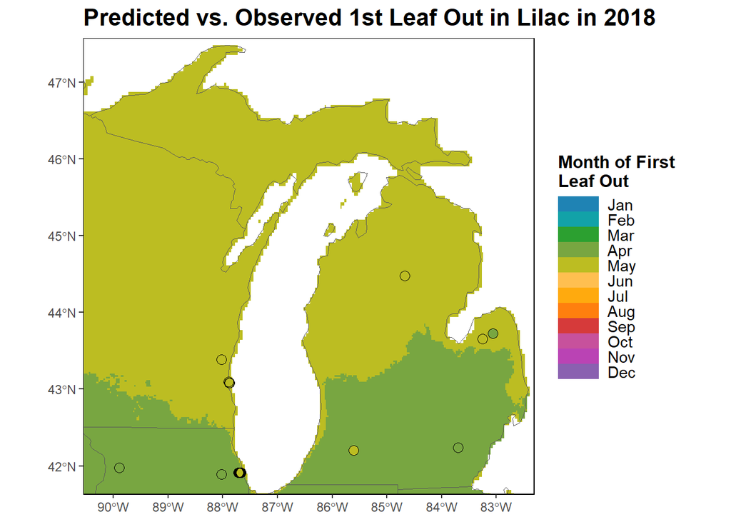

```r
# Define your limits
# Min must go before max (e.g., -180, 180)
xcoords <- c(-90.5542, -82.3047)
ycoords <- c(41.6311, 47.5739)

# Map for specific region
# The expand = FALSE ensures that limits are taken exactly as provided
conus_modVobs +
  # Define x- and y-limits
    coord_sf(xlim = xcoords, ylim = ycoords,
             expand = FALSE)
```

We can also add county boundaries by importing the shapefile in the data folder (`./data/counties.shp`). Remember to change the CRS as we did above for `states`. Also, feel free to convert the geometry to `MULTILINESTRING`.

```r
# Simple feature ("sf") for US counties
counties <- st_read(here("data", "counties.shp"))
counties <- counties %>%
  st_transform(crs = crs(states)) %>%
  st_cast("MULTILINESTRING")
```

Add the counties to your map below, remove the legend and title, and make any other desired changes. Give the map a name so it can be used for the next step.

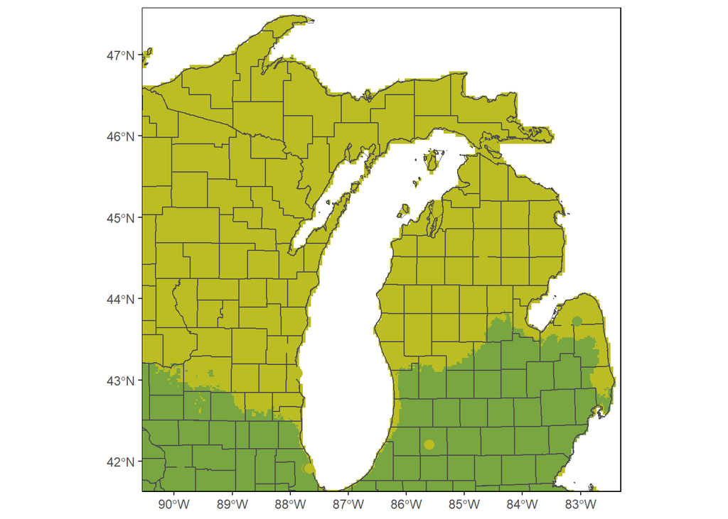

```r
# Map for region of interest
# Lilac leaf out observations are added again so boundary lines don't cover them
zoom_modVobs <- conus_modVobs +
  geom_sf(data = counties, fill = NA, color = "gray30", size = 0.25) + # Add counties
  geom_sf(data = lilacObs_sf, aes(color = leaf_month),
          size = 3, show.legend = FALSE) +
  coord_sf(xlim = c(-90.5542, -82.3047),
           ylim = c(41.6311, 47.5739),
           expand = FALSE) + # Take limits exactly as defined
  theme(legend.position = "none",
        plot.title = element_blank())
zoom_modVobs
```

Finally, we can combine maps for CONUS and your region of interest using the [`patchwork`](https://patchwork.data-imaginist.com/) package. The `\` operator indicates that the map for CONUS goes on top of the region map, the width setting indicates that the CONUS is map is 2X bigger, and the legend is “collected” to ensure it stays in the correct position (on right-hand side).

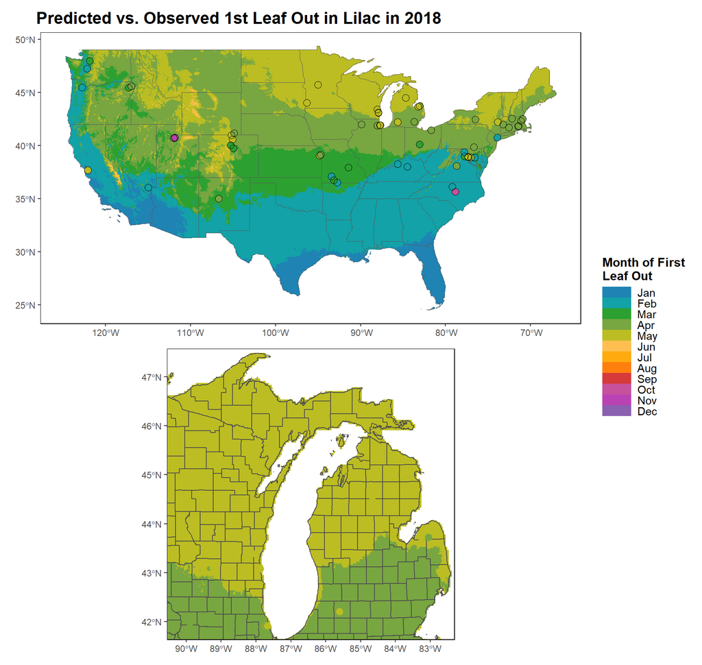

Save your map and see what you think. Feel free to adjust the theme, plot dimensions, or anything else to improve the map.

```r
ggsave(both_modVobs,
       filename = here("plots", "Lilac_leaf_out_modelVsObs_2018_2.png"),
       dpi = 300, units = c('in'), width = 9, height = 9)
```

Note: Other options for combining plots include functions in the [`ggpubr`](https://rpkgs.datanovia.com/ggpubr/) [`ggarrange()`] and [`cowplot`](https://cran.r-project.org/web/packages/cowplot/vignettes/introduction.html) [`plot_grid()`] packages.

## **Exercise 3: Extract and analyze raster data**

There are numerous functions in `terra` for extracting, manipulating, and analyzing raster data. Here, we’ll use the `extract` function to extract model predictions (predicted day of year) from the precise location where lilac observations were collected (observed day of year). This allows us to further compare the two datasets.

Extract the predictions, convert results to a data frame, and rename the data column from `layer` to `leaf_doy`.

```r
# Extract model predictions for each observation location
lilacObs_extr <- extract(lilacModel_r, lilacObs_sf) %>%
  as.data.frame() %>%
  rename("leaf_doy" = "layer") %>%
  as.data.frame()
```

Next, we can estimate the extent to which the model under-predicts vs. over-predicts the date of lilac leaf out by subtracting the `leaf_doy` columns.

```r
# Differences (in days) between predicted and observed lilac leaf out
differences <- lilacObs_extr$leaf_doy- lilacObs_sf$leaf_doy
```

Create a histogram of differences using the `hist()` function in base `R.`

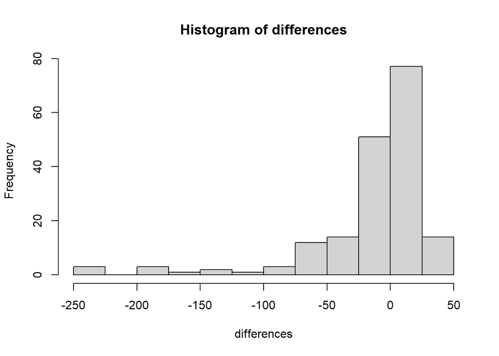

```r
hist(differences, breaks = seq(-250, 50, 25))
```

Now calculate some simple summary statistics of the differences.

```r
# Mean
mean(differences)
```

```
[1] -13.71271
```

```r
# Range
range(differences)
```

```
[1] -237   48
```

```r
# Median
median(differences)
```

```
[1] 1
```

**Question 6.** What information do your simple analyses provide that can’t be seen on a map? Overall, what do the results say about the performance of the model for lilac leaf out?

Answer: On average, predicted dates were 13.71 days earlier (range = -237 to 48 days) than observed dates, which suggests that the model is under-predicting the date of lilac leaf out. However, the extreme outliers are likely due to observer error, as we noted above. The model actually seems to perform pretty well if we reduce the impact of outliers by calculating the median difference, which is only 1 day.

## **Wrap-up**

These exercises only scratched the surface of mapping in R! Here’s a summary:

- `terra` is the most important `R` package for working with rasters:
  - `plot()` can produce maps but I prefer `ggplot2` functions for “final” (publication-quality) mapping
  - Numerous functions for extracting, manipulating, and analyzing raster data
  - Methods for manipulating data in vector form
- `ggplot2` has several functions for plotting rasters including:
  - `geom_raster()` or `geom_tile()`: require a data frame
  - `geom_spatraster()`: requires a SpatRaster object
  - `geom_stars()`: uses the `stars` package, which was not covered here

## **Potentially useful tutorials, free books, etc.**

**Compilation of various resources**  
- [R Spatial data science blogs](https://r-spatial.org/)

**Books**  
- [Using R as a GIS](https://locatepress.com/book/rgis) by N. Bearman (2025)  
- [A Crash Course in GIS using R](https://bookdown.org/michael_bcalles/gis-crash-course-in-r/) by M. Branion-Calles (2021)  
- [An Introduction to R for Spatial Analysis and Mapping](https://collegepublishing.sagepub.com/products/an-introduction-to-r-for-spatial-analysis-and-mapping-3-288946) by C. Brunsdon and L. Comber (2025)  
- [Geocomputation with R](https://r.geocompx.org/) by R. Lovelace et al. (2025)  
- [Data Analysis and Visualization with R: Spatial](http://www.geo.hunter.cuny.edu/~ssun/R-Spatial/) by S. Sun (2025)  
- [Geographic Data Science with R](https://bookdown.org/mcwimberly/gdswr-book/) by M.C. Wimberly (2023)  
- [Maps, R Not the Best Practices](https://bookdown.org/voevodin_nv/R_Not_the_Best_Practices/maps.html) by N. Voevodin (2020)

**Tutorials/vignettes**  
- [Spatial Data Science with R and “terra”](https://rspatial.org/) by R. Hijmans (2019-2025)  
- [Geospatial Data Science in R](https://zia207.github.io/geospatial-r-github.io/) by Zia Ahmed  
- [Introduction to GIS with R](https://www.jessesadler.com/post/gis-with-r-intro/) by Jesse Sadler (2018)  
- [GIS and Spatial Analysis with R](https://mgimond.github.io/MEGUG2016/Tutorial.html) by Manny Gimmond (2016)  
- [Links to vignettes and other resources](https://r-spatial.github.io/sf/) for “sf”  
- [R as GIS for Economists](https://tmieno2.github.io/R-as-GIS-for-Economists/) by Taro Mieno (2024)  
- [Geospatial workskop](https://datacarpentry.org/lessons/#geospatial) by NEON  
- [Introduction to Spatial Raster Data Using the terra Package](https://rpubs.com/GeospatialEcologist/SpatialRaster) by J. Carrell (2023)

## **Acknowledgements**

Parts of these exercises were modified from a tutorial for the [`rnpn`](https://cran.r-project.org/web/packages/rnpn/index.html) package created by Alyssa Rosemartin. Raster and observation data were downloaded from the USA National Phenology Network’s servers using `rnpn`. This work was funded by the USDA National Institute of Food and Agriculture (NIFA) Agriculture and Food Research Initiative program (grant no. 2022-68013-37138) and USDA NIFA Crop and Pest Management (CPPM) program (grant no. 2024-70006-43503).